# STATS 506 Problem Set 6

Author

Lingzhi Hao

## **GitHub Repository:** https://github.com/Lingzhi-Hao/STATS-506-Problem-Set-06

**Problem 1 - Rcpp**

```r
library(Rcpp)
```

```r
sourceCpp(code = '
#include <Rcpp.h>
using namespace Rcpp;

// [[Rcpp::export]]
double C_moment(NumericVector x, int k) {
  int n = x.size();
  if (n == 0) {
    stop("x has length 0");
  }

  double mu = 0.0;
  for (int i = 0; i < n; ++i) mu += x[i];
  mu /= n;

  double acc = 0.0;
  for (int i = 0; i < n; ++i) acc += std::pow(x[i] - mu, k);

  return acc / n;
}
')
```

```r
set.seed(123)
x <- rnorm(1000)
k <- 3

C_moment(x, k)
```

```
[1] 0.06358509
```

```r
e1071::moment(x, order = k, center = TRUE)
```

```
[1] 0.06358509
```

**Problem 2 - Expanding on waldCI**

(a)

```r
source("waldCI.R")
```

```r
setClass("bootstrapWaldCI",
         contains = "waldCI",
         slots = c(
           data = "ANY",
           statistic_fn = "function",
           reps = "numeric"
         )
)


##' Compute bootstrap Wald CI
##' @param statistic_fn Function to compute the scalar statistic of interest
##' @param data Data set to use for bootstrap
##' @param reps Number of bootstrap replicates
##' @param level Confidence level (default 0.95)
##' @param compute Computation method: "serial" or "parallel" (default "serial")
##' @return A `bootstrapWaldCI` object
##' @export
makeBootstrapCI <- function(statistic_fn,
                            data,
                            reps,
                            level = 0.95,
                            compute = "serial") {

  stopifnot(is.function(statistic_fn))
  stopifnot(is.numeric(reps) && length(reps) == 1 && reps > 0)
  stopifnot(compute %in% c("serial", "parallel"))

  boot_result <- .runBootstrap(statistic_fn, data, reps, compute)

  boot_mean <- mean(boot_result)
  boot_sterr <- sd(boot_result)

  new("bootstrapWaldCI",
      level = level,
      mean = boot_mean,
      sterr = boot_sterr,
      data = data,
      statistic_fn = statistic_fn,
      reps = reps)
}


.runBootstrap <- function(statistic_fn, data, reps, compute) {
  n <- nrow(data)

  if (compute == "serial") {
    results <- numeric(reps)
    for (i in 1:reps) {
      indices <- sample(1:n, replace = TRUE)
      boot_data <- data[indices, , drop = FALSE]
      results[i] <- statistic_fn(boot_data)
    }
    return(results)

  } else if (compute == "parallel") {
    library(parallel)

    num_cores <- detectCores() - 1
    if (num_cores < 1) num_cores <- 1
    cl <- makeCluster(num_cores, type = "PSOCK")

    clusterExport(cl, c("statistic_fn", "data", "n"), envir = environment())

    boot_run_fn <- function(i) {
      indices <- sample(1:n, replace = TRUE)
      boot_data <- data[indices, , drop = FALSE]
      statistic_fn(boot_data)
    }

    results <- parLapply(cl, 1:reps, boot_run_fn)
    stopCluster(cl)

    return(unlist(results))
  }
}



##' Perform a new bootstrap on an existing bootstrapWaldCI object
##' @param object A `bootstrapWaldCI` object
##' @return A new `bootstrapWaldCI` object
##' @export
rebootstrap <- function(object) {
  stopifnot(is(object, "bootstrapWaldCI"))

  boot_result <- .runBootstrap(object@statistic_fn,
                               data = object@data,
                               reps = object@reps,
                               compute = "serial")
  boot_mean <- mean(boot_result)
  boot_sterr <- sd(boot_result)

  return(new("bootstrapWaldCI",
             level = object@level,
             mean = boot_mean,
             sterr = boot_sterr,
             data = object@data,
             statistic_fn = object@statistic_fn,
             reps = object@reps))
}
```

(b)

```r
ci1 <- makeBootstrapCI(function(x) mean(x$y),
                       ggplot2::diamonds,
                       reps = 1000)
ci1
```

```
95% CI: (5.724897, 5.744366)
```

```r
rebootstrap(ci1)
```

```
95% CI: (5.725073, 5.744577)
```

```r
set.seed(123)

time_serial <- system.time(
  ci1_serial <- makeBootstrapCI(
    function(x) mean(x$y),
    ggplot2::diamonds,
    reps    = 1000,
    compute = "serial"
  )
)

cat("Serial Computation Results\n")
```

```
Serial Computation Results
```

```r
cat("Time:\n")
```

```
Time:
```

```r
print(time_serial)
```

```
   user  system elapsed
   5.34    0.48    7.91
```

```r
cat("CI:\n")
```

```
CI:
```

```r
ci1_serial
```

```
95% CI: (5.724917, 5.744346)
```

```r
rebootstrap(ci1_serial)
```

```
95% CI: (5.725063, 5.744586)
```

```r
set.seed(123)

time_parallel <- system.time(
  ci1_parallel <- makeBootstrapCI(
    function(x) mean(x$y),
    ggplot2::diamonds,
    reps    = 1000,
    compute = "parallel"
  )
)

cat("Parallel Computation Results\n")
```

```
Parallel Computation Results
```

```r
cat("Time:\n")
```

```
Time:
```

```r
print(time_parallel)
```

```
   user  system elapsed
   0.14    0.05   13.18
```

```r
cat("CI:\n")
```

```
CI:
```

```r
ci1_parallel
```

```
95% CI: (5.72503, 5.744101)
```

```r
rebootstrap(ci1_parallel)
```

```
95% CI: (5.724917, 5.744346)
```

Parallel computation in R has substantial overhead from creating worker processes, exporting data, and collecting results. When each bootstrap task is lightweight and the number of replications is moderate, the overhead dominates and parallel method does not run faster. If we have larger reps or more computationally expensive tasks, the parallel method would likely perform better than the serial method.

(c)

```r
##' Fits the model and returns the coefficient for disp
##' @param data A data frame
##' @return The estimated coefficient for disp
dispCoef <- function(data) {
  fit <- lm(mpg ~ cyl + disp + wt, data = data)
  return(coef(fit)["disp"])
}
```

```r
ci2 <- makeBootstrapCI(dispCoef,
                       mtcars,
                       reps = 1000)
ci2
```

```
95% CI: (-0.01005764, 0.0250501)
```

```r
rebootstrap(ci2)
```

```
95% CI: (-0.0114781, 0.02544108)
```

```r
set.seed(123)

cat("Serial Computation Results\n")
```

```
Serial Computation Results
```

```r
time_serial_c <- system.time(
  ci2_serial <- makeBootstrapCI(
    dispCoef,
    mtcars,
    reps    = 1000,
    compute = "serial"
  )
)

cat("Serial Compute Time (seconds):", time_serial_c["elapsed"], "\n")
```

```
Serial Compute Time (seconds): 0.92
```

```r
cat("CI:\n")
```

```
CI:
```

```r
ci2_serial
```

```
95% CI: (-0.01111183, 0.02598235)
```

```r
rebootstrap(ci2_serial)
```

```
95% CI: (-0.01230038, 0.02644671)
```

```r
cat("\nParallel Computation Results\n")
```

```
Parallel Computation Results
```

```r
set.seed(123)

time_parallel_c <- system.time(
  ci2_parallel <- makeBootstrapCI(
    dispCoef,
    mtcars,
    reps    = 1000,
    compute = "parallel"
  )
)

cat("Parallel Compute Time (seconds):", time_parallel_c["elapsed"], "\n")
```

```
Parallel Compute Time (seconds): 0.64
```

```r
cat("CI:\n")
```

```
CI:
```

```r
ci2_parallel
```

```
95% CI: (-0.01072328, 0.02558667)
```

```r
rebootstrap(ci2_parallel)
```

```
95% CI: (-0.01111183, 0.02598235)
```

**Problem 3 - Large data**

(a)

```
Data.frame `df` is 251.8 Mb
```

```r
library(lme4)
library(dplyr)
library(ggplot2)
```

```r
countries <- unique(df$country)

results <- list()
coef_forum <- data.frame()

for (c in countries) {
  cat("Fitting model for country:", c, "\n")

  sub <- df %>% filter(country == c)

  sub <- sub %>%
    mutate(
      prior_gpa_z      = scale(prior_gpa),
      forum_posts_z    = scale(forum_posts),
      quiz_attempts_z  = scale(quiz_attempts)
    )

  t <- system.time({
    fit <- glmer(
      completed_course ~ prior_gpa_z + forum_posts_z + quiz_attempts_z +
        (1 | device_type),
      data = sub,
      family = binomial()
    )
  })

  results[[c]] <- list(model = fit, time = t)

  coef_forum <- rbind(
    coef_forum,
    data.frame(
      country = c,
      estimate = fixef(fit)["forum_posts_z"],
      time_sec = t["elapsed"]
    )
  )
}
```

```
Fitting model for country: US
Fitting model for country: Other
Fitting model for country: India
Fitting model for country: Germany
Fitting model for country: Lithuania
Fitting model for country: Nigeria
```

```r
coef_forum
```

```
                 country  estimate time_sec
forum_posts_z         US 0.1781708   285.53
forum_posts_z1     Other 0.1751446   515.36
forum_posts_z2     India 0.1761594   207.46
forum_posts_z3   Germany 0.1765869   132.15
forum_posts_z4 Lithuania 0.1747332     3.87
forum_posts_z5   Nigeria 0.1916254     8.56
```

The running time of the six models are on the table above as time_sec.

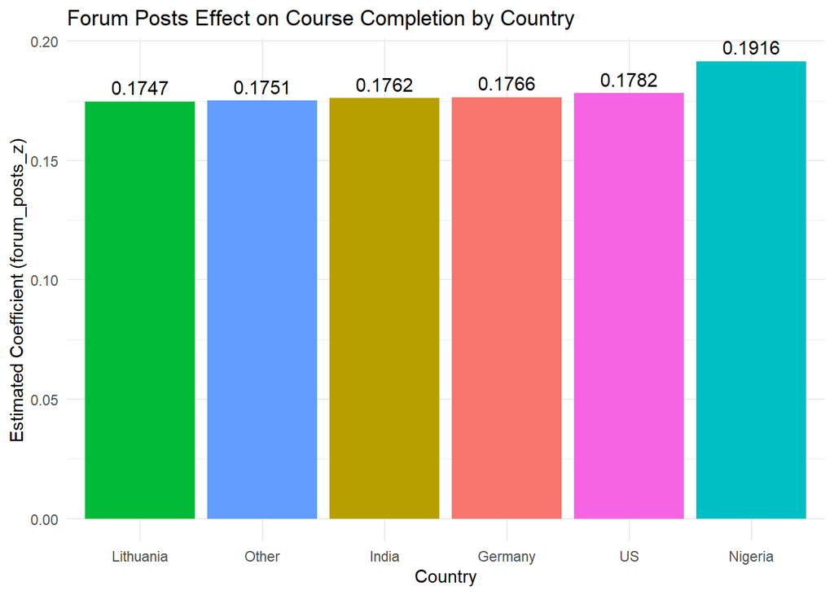

```r
ggplot(coef_forum, aes(x = reorder(country, estimate),
                       y = estimate,
                       fill = country)) +

  geom_col() +

  geom_text(aes(label = round(estimate, 4)),
            vjust = -0.5,
            size = 4) +

  theme_minimal() +

  labs(
    title = "Forum Posts Effect on Course Completion by Country",
    y = "Estimated Coefficient (forum_posts_z)",
    x = "Country"
  ) +

  theme(legend.position = "none")
```

(b)

```r
library(parallel)

detectCores()
```

```
[1] 8
```

```r
total_time <- system.time({

  source("problem_set_6_gen_data.R")

  df2 <- df %>%
    group_by(country) %>%
    mutate(
      prior_gpa_z     = as.numeric(scale(prior_gpa)),
      forum_posts_z   = as.numeric(scale(forum_posts)),
      quiz_attempts_z = as.numeric(scale(quiz_attempts))
    ) %>%
    ungroup()

  fit_country_model_par <- function(c) {
    library(lme4)
    library(dplyr)

    sub <- df2 %>% filter(country == c)

    t <- system.time({
      fit <- glmer(
        completed_course ~ prior_gpa_z + forum_posts_z + quiz_attempts_z +
          (1 | device_type),
        data = sub,
        family = binomial()
      )
    })

    data.frame(
      country = c,
      estimate = fixef(fit)["forum_posts_z"],
      time_sec_fit = t["elapsed"]
    )
  }

  countries_list <- unique(df2$country)
  num_cores <- detectCores() - 1

  cl <- makeCluster(num_cores, type = "PSOCK")

  clusterExport(cl, "df2", envir = environment())
  clusterEvalQ(cl, {
    library(lme4)
    library(dplyr)
  })

  parallel_results_list <- parLapply(cl, countries_list, fit_country_model_par)

  stopCluster(cl)

  optimized_coef_parallel <- bind_rows(parallel_results_list)

})
```

```
Data.frame `df` is 251.8 Mb
```

```r
cat("Total running time:\n")
```

```
Total running time:
```

```r
print(total_time)
```

```
   user  system elapsed
   5.83    3.20  652.68
```

```r
print(optimized_coef_parallel)
```

```
                    country  estimate time_sec_fit
forum_posts_z...1        US 0.1781708       398.02
forum_posts_z...2     Other 0.1751446       634.57
forum_posts_z...3     India 0.1761594       326.92
forum_posts_z...4   Germany 0.1765869       213.09
forum_posts_z...5 Lithuania 0.1747332         5.50
forum_posts_z...6   Nigeria 0.1916254        13.05
```

```r
coef_a <- coef_forum %>% arrange(country)
coef_b <- optimized_coef_parallel %>% arrange(country)

all.equal(coef_a$estimate, coef_b$estimate)
```

```
[1] TRUE
```

The results of (b) matches those from (a).

**Problem 4 - data.table**

```r
library(data.table)
ATP_Matches = fread("https://raw.githubusercontent.com/JeffSackmann/tennis_atp/refs/heads/master/atp_matches_2019.csv")
```

(a)

```r
ATP_Matches[, .N, by = tourney_id][, .N]
```

```
[1] 128
```

*128* tournaments are in the *atp_matches_2019* dataset. We assume the tournaments with dates in 2018 are part of tournaments in 2019.

```r
library(stringr)

ATP_Matches[str_detect(tourney_name, "Davis Cup")][1:5]
```

```
                          tourney_id                    tourney_name surface
                              <char>                          <char>  <char>
1: 2019-M-DC-2019-FLS-A-M-FRA-JPN-01 Davis Cup Finals RR: FRA vs JPN    Hard
2: 2019-M-DC-2019-FLS-A-M-FRA-JPN-01 Davis Cup Finals RR: FRA vs JPN    Hard
3: 2019-M-DC-2019-FLS-A-M-FRA-SRB-01 Davis Cup Finals RR: FRA vs SRB    Hard
4: 2019-M-DC-2019-FLS-A-M-FRA-SRB-01 Davis Cup Finals RR: FRA vs SRB    Hard
5: 2019-M-DC-2019-FLS-A-M-SRB-JPN-01 Davis Cup Finals RR: SRB vs JPN    Hard
   draw_size tourney_level tourney_date match_num winner_id winner_seed
       <int>        <char>        <int>     <int>     <int>       <int>
1:         4             D     20191119         1    104542          NA
2:         4             D     20191119         2    106415          NA
3:         4             D     20191121         1    105936          NA
4:         4             D     20191121         2    104925          NA
5:         4             D     20191120         1    105936          NA
   winner_entry        winner_name winner_hand winner_ht winner_ioc winner_age
```

[output cut: 41 more lines]

```r
tourneys <- ATP_Matches[, tourney_name := str_replace(tourney_name, "Davis.*", "Davis Cup")]
tourneys <- tourneys[, .(tourney_name), by = tourney_name]

nrow(tourneys)
```

```
[1] 69
```

There are *69* unique tournaments.

(b)

If we only consider the tournaments with a final round “F”, there are *67* such tournaments. And assume the winner of a tournaments is who wins round “F”.

```r
ATP_Matches[round == "F", .N]
```

```
[1] 67
```

*12* players won more than one tournaments. The most winning players Dominic Thiem and Novak Djokovic both won *5* tournaments.

```r
ATP_Matches[round == "F", .N, by = winner_name][N > 1][order(-N)]
```

```
           winner_name     N
                <char> <int>
 1:     Novak Djokovic     5
 2:      Dominic Thiem     5
 3:    Daniil Medvedev     4
 4:      Roger Federer     4
 5:       Rafael Nadal     4
 6:     Alex De Minaur     3
 7: Stefanos Tsitsipas     3
 8: Jo-Wilfried Tsonga     2
 9:       Nick Kyrgios     2
10:     Cristian Garin     2
11:       Benoit Paire     2
12:  Matteo Berrettini     2
```

If we consider winners of the round with maximum match number, there are 61 tournaments only having round “RR”.

```r
ATP_Matches[order(tourney_id, -match_num), .SD[1], by = tourney_id][, .N, by = round]
```

```
    round     N
   <char> <int>
1:      F    67
2:     RR    61
```

```r
ATP_Matches[order(tourney_name, -match_num)][, .SD[1], by = tourney_id][, .(wins = .N), by = winner_name][order(-wins)][wins > 1]
```

```
           winner_name  wins
                <char> <int>
 1:       Rafael Nadal     9
 2:     Novak Djokovic     8
 3:     Alex De Minaur     6
 4:      Dominic Thiem     5
 5:      Roger Federer     4
 6:    Daniil Medvedev     4
 7:     Cristian Garin     4
 8:   Denis Shapovalov     4
 9:        Robin Haase     3
10: Stefanos Tsitsipas     3
11:       Nick Kyrgios     2
12:  Matteo Berrettini     2
13:    Karen Khachanov     2
14:  Diego Schwartzman     2
15:       Taylor Fritz     2
16:       Benoit Paire     2
17: Jo-Wilfried Tsonga     2
```

*17* players won more than one tournaments. The most winning player Rafael Nadal won 9 tournaments.

(c)

There is evidence that winners have more aces than losers.

```r
library(tidymodels)
ATP_Matches[, mean(w_ace > l_ace, na.rm = TRUE)]
```

```
[1] 0.5727543
```

```r
prop_test(ATP_Matches[, .(win_more = w_ace > l_ace)], win_more ~ NULL, p = 0.5)
```

```
# A tibble: 1 × 4
  statistic chisq_df  p_value alternative
      <dbl>    <int>    <dbl> <chr>
1      56.7        1 4.95e-14 two.sided
```

We define `win_more = (w_ace > l_ace)` and conduct a one-sample proportion test with  
H0: P(win_more) = 0.5, H1: P(win_more) != 0.5.

The sample proportion of matches in which winners record more aces is: mean(win_more) = 0.57 > 0.5

(d)

The player (at least 5 matches) with highest win-rate is *Rafael Nadal*.

```r
ATP_Matches[
  , melt(.SD,
         measure.vars = c("winner_name", "loser_name"),
         variable.name = "outcome",
         value.name   = "player_name")
][
  , .(
      total = .N,
      wins  = sum(outcome == "winner_name")
    ),
  by = player_name
][
  total >= 5
][
  , win_rate := wins / total
][
  win_rate == max(win_rate)
]
```

```
    player_name total  wins  win_rate
         <char> <int> <int>     <num>
1: Rafael Nadal    69    60 0.8695652
```